# Task 5 Karis Saplys

Karis Saplys

2022-09-05

```r
library(readr)
library(tidyverse)
library(knitr)
library(downloader)
library(dplyr)
```

```r
SoloData <- read_csv("solo-artist-followers.csv")
SoloData
```

```
## # A tibble: 139 × 5
##    name              band                followers band_followers follower_dif…¹
##    <chr>             <chr>               <chr>     <chr>          <chr>
##  1 Daron Jones       112                 1.28k     783k           −782k
##  2 Slim              112                 2.14k     783k           −781k
##  3 Q Parker          112                 3.51k     783k           −780k
##  4 JC Chasez         *NSYNC              30.8k     1.44M          −1.41M
##  5 Joey Fatone       *NSYNC              1.13k     1.44M          −1.44M
##  6 Justin Timberlake *NSYNC              10.3M     1.44M          8.90M
##  7 Ashton Irwin      5 Seconds of Summer 130k      7.14M          −7.01M
##  8 Abz Love          5ive                223       19.0k          −18.7k
##  9 Jeff Timmons      98º                 111       302k           −302k
## 10 Nick Lachey       98º                 142k      302k           −160k
## # … with 129 more rows, and abbreviated variable name ¹follower_difference
```

```r
str(SoloData)
```

```
## spec_tbl_df [139 × 5] (S3: spec_tbl_df/tbl_df/tbl/data.frame)
##  $ name               : chr [1:139] "Daron Jones" "Slim" "Q Parker" "JC Chasez" ...
##  $ band               : chr [1:139] "112" "112" "112" "*NSYNC" ...
##  $ followers          : chr [1:139] "1.28k" "2.14k" "3.51k" "30.8k" ...
##  $ band_followers     : chr [1:139] "783k" "783k" "783k" "1.44M" ...
##  $ follower_difference: chr [1:139] "−782k" "−781k" "−780k" "−1.41M" ...
##  - attr(*, "spec")=
##   .. cols(
##   ..   name = col_character(),
##   ..   band = col_character(),
##   ..   followers = col_character(),
##   ..   band_followers = col_character(),
##   ..   follower_difference = col_character()
##   .. )
##  - attr(*, "problems")=<externalptr>
```

Data imported correctly as characters.

```r
BillboardData <- read_csv("billboard-hits.csv")
BillboardData
```

```
## # A tibble: 456 × 5
##    name   band  title                     peak_date  peak_rank
##    <chr>  <chr> <chr>                     <date>         <dbl>
##  1 *NSYNC <NA>  It's Gonna Be Me          2000-07-28         1
##  2 *NSYNC <NA>  Music Of My Heart         1999-10-15         2
##  3 *NSYNC <NA>  Bye Bye Bye               2000-04-14         4
##  4 *NSYNC <NA>  This I Promise You        2000-12-01         5
##  5 *NSYNC <NA>  Girlfriend                2002-04-05         5
##  6 *NSYNC <NA>  A Little More Time On You 1999-02-26         8
##  7 *NSYNC <NA>  Gone                      2001-11-23        11
##  8 *NSYNC <NA>  I Want You Back           1998-05-01        13
##  9 *NSYNC <NA>  Pop                       2001-06-15        19
## 10 *NSYNC <NA>  Tearin' Up My Heart       1998-12-04        59
## # … with 446 more rows
```

```r
str("BillboardData")
```

```
##  chr "BillboardData"
```

```r
sixtop100hits <- BillboardData %>%
  group_by(name) %>%
  filter(n() > 6, band != "")
sixtop100hits
```

```
## # A tibble: 144 × 5
## # Groups:   name [10]
##    name              band   title                           peak_date  peak_rank
##    <chr>             <chr>  <chr>                           <date>         <dbl>
##  1 Justin Timberlake *NSYNC SexyBack                        2006-09-08         1
##  2 Justin Timberlake *NSYNC My Love                         2006-11-10         1
##  3 Justin Timberlake *NSYNC What Goes Around...Comes Around 2007-03-02         1
##  4 Justin Timberlake *NSYNC Can't Stop The Feeling!         2016-05-27         1
##  5 Justin Timberlake *NSYNC Mirrors                         2013-06-14         2
##  6 Justin Timberlake *NSYNC Cry Me A River                  2003-01-31         3
##  7 Justin Timberlake *NSYNC Suit & Tie                      2013-04-05         3
##  8 Justin Timberlake *NSYNC Rock Your Body                  2003-05-09         5
##  9 Justin Timberlake *NSYNC Summer Love                     2007-06-08         6
## 10 Justin Timberlake *NSYNC Not A Bad Thing                 2014-05-02         8
## # … with 134 more rows
```

Singers without 6 top 100 hits removed.

```r
sixtop100_bands <- BillboardData %>%
  group_by(name) %>%
  filter(name %in% sixtop100hits$band)
sixtop100_bands
```

```
## # A tibble: 101 × 5
## # Groups:   name [8]
##    name   band  title                     peak_date  peak_rank
##    <chr>  <chr> <chr>                     <date>         <dbl>
##  1 *NSYNC <NA>  It's Gonna Be Me          2000-07-28         1
##  2 *NSYNC <NA>  Music Of My Heart         1999-10-15         2
##  3 *NSYNC <NA>  Bye Bye Bye               2000-04-14         4
##  4 *NSYNC <NA>  This I Promise You        2000-12-01         5
##  5 *NSYNC <NA>  Girlfriend                2002-04-05         5
##  6 *NSYNC <NA>  A Little More Time On You 1999-02-26         8
##  7 *NSYNC <NA>  Gone                      2001-11-23        11
##  8 *NSYNC <NA>  I Want You Back           1998-05-01        13
##  9 *NSYNC <NA>  Pop                       2001-06-15        19
## 10 *NSYNC <NA>  Tearin' Up My Heart       1998-12-04        59
## # … with 91 more rows
```

Corresponding data in the data set for the top singers’ bands.

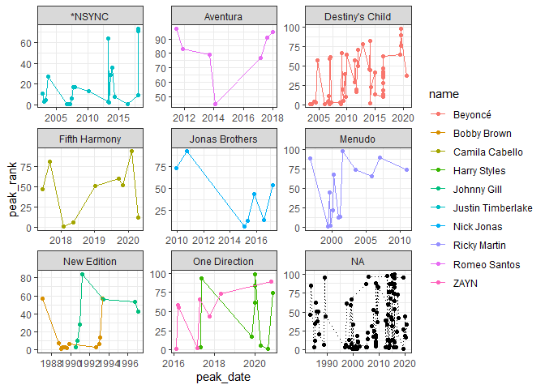

```r
ggplot(data = sixtop100hits, mapping=aes(x = peak_date, y = peak_rank, color = name, group = name)) +
  geom_point() +
  geom_line() +
  geom_point(data = sixtop100_bands, color = "black") +
  geom_line(data = sixtop100_bands, color = "black", linetype = "dotted") +
  facet_wrap(~ band, scales = "free") +
  xlab("peak_date") + ylab("peak_rank") +
  theme_bw()
```

```r
climate_data <- read_csv("Climate Data.csv")
```

```
## ──────────────────────────────────────────────────────── Delimiter: "," chr
## (2): Year, Troposphere dbl (28): Mo, Globe, Land...4, Ocean...5, NH, Land...7,
## Ocean...8, SH, Land....
```

```r
head(climate_data)
```

```
## # A tibble: 6 × 30
##   Year     Mo Globe Land...4 Ocean…¹    NH Land.…² Ocean…³    SH Land.…⁴ Ocean…⁵
##   <chr> <dbl> <dbl>    <dbl>   <dbl> <dbl>   <dbl>   <dbl> <dbl>   <dbl>   <dbl>
## 1 1978     12 -0.48    -0.51   -0.47 -0.44   -0.46   -0.42 -0.52   -0.62   -0.5
## 2 1979      1 -0.47    -0.64   -0.41 -0.64   -0.86   -0.5  -0.31   -0.13   -0.34
## 3 1979      2 -0.43    -0.56   -0.39 -0.47   -0.57   -0.41 -0.39   -0.53   -0.37
## 4 1979      3 -0.38    -0.51   -0.33 -0.46   -0.51   -0.44 -0.3    -0.53   -0.26
## 5 1979      4 -0.4     -0.57   -0.34 -0.47   -0.62   -0.37 -0.34   -0.46   -0.31
## 6 1979      5 -0.4     -0.56   -0.33 -0.52   -0.54   -0.52 -0.27   -0.62   -0.19
## # … with 19 more variables: Trpcs <dbl>, Land...13 <dbl>, Ocean...14 <dbl>,
## #   NoExt <dbl>, Land...16 <dbl>, Ocean...17 <dbl>, SoExt <dbl>,
## #   Land...19 <dbl>, Ocean...20 <dbl>, NoPol <dbl>, Land...22 <dbl>,
## #   Ocean...23 <dbl>, SoPol <dbl>, Land...25 <dbl>, Ocean...26 <dbl>,
## #   USA48 <dbl>, USA49 <dbl>, AUST <dbl>, Troposphere <chr>, and abbreviated
## #   variable names ¹Ocean...5, ²Land...7, ³Ocean...8, ⁴Land...10, ⁵Ocean...11
```

```r
str(climate_data)
```

```
## spec_tbl_df [2,105 × 30] (S3: spec_tbl_df/tbl_df/tbl/data.frame)
##  $ Year       : chr [1:2105] "1978" "1979" "1979" "1979" ...
##  $ Mo         : num [1:2105] 12 1 2 3 4 5 6 7 8 9 ...
##  $ Globe      : num [1:2105] -0.48 -0.47 -0.43 -0.38 -0.4 -0.4 -0.39 -0.31 -0.4 -0.32 ...
##  $ Land...4   : num [1:2105] -0.51 -0.64 -0.56 -0.51 -0.57 -0.56 -0.61 -0.57 -0.54 -0.44 ...
##  $ Ocean...5  : num [1:2105] -0.47 -0.41 -0.39 -0.33 -0.34 -0.33 -0.31 -0.21 -0.35 -0.28 ...
##  $ NH         : num [1:2105] -0.44 -0.64 -0.47 -0.46 -0.47 -0.52 -0.5 -0.21 -0.34 -0.33 ...
##  $ Land...7   : num [1:2105] -0.46 -0.86 -0.57 -0.51 -0.62 -0.54 -0.61 -0.33 -0.37 -0.31 ...
##  $ Ocean...8  : num [1:2105] -0.42 -0.5 -0.41 -0.44 -0.37 -0.52 -0.44 -0.14 -0.32 -0.34 ...
##  $ SH         : num [1:2105] -0.52 -0.31 -0.39 -0.3 -0.34 -0.27 -0.29 -0.41 -0.46 -0.32 ...
##  $ Land...10  : num [1:2105] -0.62 -0.13 -0.53 -0.53 -0.46 -0.62 -0.62 -1.11 -0.91 -0.73 ...
##  $ Ocean...11 : num [1:2105] -0.5 -0.34 -0.37 -0.26 -0.31 -0.19 -0.22 -0.26 -0.36 -0.23 ...
##  $ Trpcs      : num [1:2105] -0.6 -0.47 -0.36 -0.36 -0.35 -0.46 -0.37 -0.41 -0.37 -0.35 ...
##  $ Land...13  : num [1:2105] -0.62 -0.54 -0.25 -0.43 -0.37 -0.55 -0.49 -0.55 -0.35 -0.42 ...
##  $ Ocean...14 : num [1:2105] -0.59 -0.45 -0.39 -0.34 -0.34 -0.43 -0.33 -0.37 -0.38 -0.33 ...
##  $ NoExt      : num [1:2105] -0.37 -0.73 -0.54 -0.53 -0.54 -0.54 -0.55 -0.15 -0.36 -0.33 ...
##  $ Land...16  : num [1:2105] -0.44 -0.93 -0.67 -0.53 -0.72 -0.52 -0.63 -0.33 -0.43 -0.29 ...
##  $ Ocean...17 : num [1:2105] -0.3 -0.55 -0.42 -0.52 -0.38 -0.56 -0.48 0.01 -0.3 -0.36 ...
##  $ SoExt      : num [1:2105] -0.46 -0.23 -0.41 -0.26 -0.33 -0.18 -0.27 -0.37 -0.47 -0.29 ...
##  $ Land...19  : num [1:2105] -0.55 0.12 -0.69 -0.59 -0.43 -0.7 -0.74 -1.34 -1.17 -0.95 ...
##  $ Ocean...20 : num [1:2105] -0.45 -0.29 -0.36 -0.21 -0.31 -0.09 -0.19 -0.2 -0.34 -0.17 ...
##  $ NoPol      : num [1:2105] -0.39 -0.46 -2.01 -0.56 -0.84 -0.77 -0.76 -0.2 -0.26 -0.18 ...
##  $ Land...22  : num [1:2105] -0.68 -0.95 -2.3 -0.47 -0.81 -0.56 -1.14 -0.38 -0.35 -0.02 ...
##  $ Ocean...23 : num [1:2105] -0.06 0.1 -1.66 -0.65 -0.88 -1 -0.33 0.01 -0.15 -0.35 ...
##  $ SoPol      : num [1:2105] -0.45 -0.16 -0.8 -0.52 -0.26 0.05 -0.98 -0.95 -1 -0.11 ...
##  $ Land...25  : num [1:2105] -0.38 -0.15 -1.25 -1.25 0.26 -0.42 -1.62 -2.18 -1.67 -0.65 ...
##  $ Ocean...26 : num [1:2105] -0.49 -0.16 -0.58 -0.18 -0.51 0.27 -0.67 -0.37 -0.69 0.15 ...
##  $ USA48      : num [1:2105] -1.29 -3.22 -1.76 -0.7 -0.72 -0.82 -0.62 -0.16 -0.74 0.61 ...
##  $ USA49      : num [1:2105] -1.15 -2.42 -1.84 -0.39 -0.46 -0.75 -0.67 -0.09 -0.36 0.68 ...
##  $ AUST       : num [1:2105] -1.29 0.92 -0.3 0.23 -1.12 -1.1 -0.56 -1.16 -1.05 -0.76 ...
##  $ Troposphere: chr [1:2105] "Lower" "Lower" "Lower" "Lower" ...
##  - attr(*, "spec")=
##   .. cols(
##   ..   Year = col_character(),
##   ..   Mo = col_double(),
##   ..   Globe = col_double(),
##   ..   Land...4 = col_double(),
##   ..   Ocean...5 = col_double(),
##   ..   NH = col_double(),
##   ..   Land...7 = col_double(),
```

[output cut: 10 more lines]

```
##   ..   SoExt = col_double(),
##   ..   Land...19 = col_double(),
##   ..   Ocean...20 = col_double(),
##   ..   NoPol = col_double(),
##   ..   Land...22 = col_double(),
##   ..   Ocean...23 = col_double(),
##   ..   SoPol = col_double(),
##   ..   Land...25 = col_double(),
##   ..   Ocean...26 = col_double(),
##   ..   USA48 = col_double(),
##   ..   USA49 = col_double(),
##   ..   AUST = col_double(),
##   ..   Troposphere = col_character()
##   .. )
##  - attr(*, "problems")=<externalptr>
```

https://www.kaggle.com/datasets/csafrit2/latest-global-temperatures

The above dataset contains NOAA satelite data measuring natural microwave thermal emissions from various layers of the atmosphere. The data comes from 15 different instruments, and is updated every year to show changes in atmospheric temperatures.

```r
rent_index1 <- read_csv("price.csv")
rent_index2 <- read_csv("pricepersqft.csv")
head(rent_index1)
```

```
## # A tibble: 6 × 81
##   `City Code` City    Metro County State Popul…¹ Novem…² Decem…³ Janua…⁴ Febru…⁵
##         <dbl> <chr>   <chr> <chr>  <chr>   <dbl>   <dbl>   <dbl>   <dbl>   <dbl>
## 1        6181 New Yo… New … Queens NY          1      NA      NA      NA      NA
## 2       12447 Los An… Los … Los A… CA          2    2184    2184    2183    2188
## 3       17426 Chicago Chic… Cook   IL          3    1563    1555    1547    1537
## 4       39051 Houston Hous… Harris TX          4    1198    1199    1199    1200
## 5       13271 Philad… Phil… Phila… PA          5    1092    1099    1094    1087
## 6       40326 Phoenix Phoe… Maric… AZ          6    1087    1080    1071    1067
## # … with 71 more variables: `March 2011` <dbl>, `April 2011` <dbl>,
## #   `May 2011` <dbl>, `June 2011` <dbl>, `July 2011` <dbl>,
## #   `August 2011` <dbl>, `September 2011` <dbl>, `October 2011` <dbl>,
## #   `November 2011` <dbl>, `December 2011` <dbl>, `January 2012` <dbl>,
## #   `February 2012` <dbl>, `March 2012` <dbl>, `April 2012` <dbl>,
## #   `May 2012` <dbl>, `June 2012` <dbl>, `July 2012` <dbl>,
## #   `August 2012` <dbl>, `September 2012` <dbl>, `October 2012` <dbl>, …
```

```r
head(rent_index2)
```

```
## # A tibble: 6 × 81
##   `City Code` City    Metro County State Popul…¹ Novem…² Decem…³ Janua…⁴ Febru…⁵
##         <dbl> <chr>   <chr> <chr>  <chr>   <dbl>   <dbl>   <dbl>   <dbl>   <dbl>
## 1        6181 New Yo… New … Queens NY          1  NA      NA      NA      NA
## 2       12447 Los An… Los … Los A… CA          2   1.58    1.58    1.58    1.58
## 3       17426 Chicago Chic… Cook   IL          3   1.24    1.25    1.25    1.25
## 4       39051 Houston Hous… Harris TX          4   0.788   0.784   0.784   0.786
## 5       13271 Philad… Phil… Phila… PA          5   0.854   0.858   0.858   0.858
## 6       40326 Phoenix Phoe… Maric… AZ          6   0.764   0.766   0.766   0.766
## # … with 71 more variables: `March 2011` <dbl>, `April 2011` <dbl>,
## #   `May 2011` <dbl>, `June 2011` <dbl>, `July 2011` <dbl>,
## #   `August 2011` <dbl>, `September 2011` <dbl>, `October 2011` <dbl>,
## #   `November 2011` <dbl>, `December 2011` <dbl>, `January 2012` <dbl>,
## #   `February 2012` <dbl>, `March 2012` <dbl>, `April 2012` <dbl>,
## #   `May 2012` <dbl>, `June 2012` <dbl>, `July 2012` <dbl>,
## #   `August 2012` <dbl>, `September 2012` <dbl>, `October 2012` <dbl>, …
```

```r
str(rent_index1)
```

```
## spec_tbl_df [13,131 × 81] (S3: spec_tbl_df/tbl_df/tbl/data.frame)
##  $ City Code      : num [1:13131] 6181 12447 17426 39051 13271 ...
##  $ City           : chr [1:13131] "New York" "Los Angeles" "Chicago" "Houston" ...
##  $ Metro          : chr [1:13131] "New York" "Los Angeles" "Chicago" "Houston" ...
##  $ County         : chr [1:13131] "Queens" "Los Angeles" "Cook" "Harris" ...
##  $ State          : chr [1:13131] "NY" "CA" "IL" "TX" ...
##  $ Population Rank: num [1:13131] 1 2 3 4 5 6 7 8 9 10 ...
##  $ November 2010  : num [1:13131] NA 2184 1563 1198 1092 ...
##  $ December 2010  : num [1:13131] NA 2184 1555 1199 1099 ...
##  $ January 2011   : num [1:13131] NA 2183 1547 1199 1094 ...
##  $ February 2011  : num [1:13131] NA 2188 1537 1200 1087 ...
##  $ March 2011     : num [1:13131] NA 2189 1526 1203 1080 ...
##  $ April 2011     : num [1:13131] NA 2189 1517 1205 1080 ...
##  $ May 2011       : num [1:13131] NA 2188 1507 1204 1083 ...
##  $ June 2011      : num [1:13131] NA 2191 1497 1199 1082 ...
##  $ July 2011      : num [1:13131] NA 2189 1493 1194 1082 ...
##  $ August 2011    : num [1:13131] NA 2186 1491 1190 1085 ...
##  $ September 2011 : num [1:13131] NA 2183 1489 1188 1095 ...
##  $ October 2011   : num [1:13131] NA 2183 1485 1186 1098 ...
##  $ November 2011  : num [1:13131] NA 2182 1480 1188 1094 ...
##  $ December 2011  : num [1:13131] 1746 2178 1483 1190 1085 ...
##  $ January 2012   : num [1:13131] 1752 2172 1484 1194 1080 ...
##  $ February 2012  : num [1:13131] 1764 2175 1485 1196 1083 ...
##  $ March 2012     : num [1:13131] 1778 2177 1489 1199 1087 ...
##  $ April 2012     : num [1:13131] 1792 2183 1494 1200 1091 ...
##  $ May 2012       : num [1:13131] 1804 2186 1496 1199 1092 ...
##  $ June 2012      : num [1:13131] 1813 2190 1493 1197 1094 ...
##  $ July 2012      : num [1:13131] 1814 2192 1491 1193 1096 ...
##  $ August 2012    : num [1:13131] 1810 2189 1491 1193 1095 ...
##  $ September 2012 : num [1:13131] 1805 2189 1498 1197 1092 ...
##  $ October 2012   : num [1:13131] 1806 2185 1509 1201 1090 ...
##  $ November 2012  : num [1:13131] 1817 2183 1513 1203 1089 ...
##  $ December 2012  : num [1:13131] 1831 2186 1517 1199 1087 ...
##  $ January 2013   : num [1:13131] 1851 2194 1514 1201 1083 ...
##  $ February 2013  : num [1:13131] 1870 2203 1511 1208 1081 ...
##  $ March 2013     : num [1:13131] 1888 2212 1512 1218 1083 ...
##  $ April 2013     : num [1:13131] 1901 2222 1527 1227 1089 ...
##  $ May 2013       : num [1:13131] 1918 2229 1544 1236 1093 ...
##  $ June 2013      : num [1:13131] 1941 2236 1560 1248 1095 ...
##  $ July 2013      : num [1:13131] 1968 2239 1562 1258 1094 ...
```

[output cut: 112 more lines]

```
##   ..   `January 2016` = col_double(),
##   ..   `February 2016` = col_double(),
##   ..   `March 2016` = col_double(),
##   ..   `April 2016` = col_double(),
##   ..   `May 2016` = col_double(),
##   ..   `June 2016` = col_double(),
##   ..   `July 2016` = col_double(),
##   ..   `August 2016` = col_double(),
##   ..   `September 2016` = col_double(),
##   ..   `October 2016` = col_double(),
##   ..   `November 2016` = col_double(),
##   ..   `December 2016` = col_double(),
##   ..   `January 2017` = col_double()
##   .. )
##  - attr(*, "problems")=<externalptr>
```

```r
str(rent_index2)
```

```
## spec_tbl_df [11,919 × 81] (S3: spec_tbl_df/tbl_df/tbl/data.frame)
##  $ City Code      : num [1:11919] 6181 12447 17426 39051 13271 ...
##  $ City           : chr [1:11919] "New York" "Los Angeles" "Chicago" "Houston" ...
##  $ Metro          : chr [1:11919] "New York" "Los Angeles" "Chicago" "Houston" ...
##  $ County         : chr [1:11919] "Queens" "Los Angeles" "Cook" "Harris" ...
##  $ State          : chr [1:11919] "NY" "CA" "IL" "TX" ...
##  $ Population Rank: num [1:11919] 1 2 3 4 5 6 7 8 9 10 ...
##  $ November 2010  : num [1:11919] NA 1.578 1.244 0.788 0.854 ...
##  $ December 2010  : num [1:11919] NA 1.578 1.248 0.784 0.858 ...
##  $ January 2011   : num [1:11919] NA 1.58 1.254 0.784 0.858 ...
##  $ February 2011  : num [1:11919] NA 1.582 1.254 0.786 0.858 ...
##  $ March 2011     : num [1:11919] NA 1.586 1.248 0.792 0.856 ...
##  $ April 2011     : num [1:11919] NA 1.588 1.24 0.796 0.854 ...
##  $ May 2011       : num [1:11919] NA 1.59 1.232 0.796 0.854 ...
##  $ June 2011      : num [1:11919] NA 1.594 1.224 0.794 0.852 ...
##  $ July 2011      : num [1:11919] NA 1.594 1.22 0.788 0.85 ...
##  $ August 2011    : num [1:11919] NA 1.594 1.212 0.784 0.848 ...
##  $ September 2011 : num [1:11919] NA 1.592 1.206 0.778 0.85 ...
##  $ October 2011   : num [1:11919] NA 1.59 1.194 0.772 0.85 ...
##  $ November 2011  : num [1:11919] NA 1.592 1.188 0.772 0.852 ...
##  $ December 2011  : num [1:11919] 1.39 1.592 1.18 0.776 0.852 ...
##  $ January 2012   : num [1:11919] 1.388 1.59 1.176 0.776 0.854 ...
##  $ February 2012  : num [1:11919] 1.392 1.588 1.174 0.78 0.858 ...
##  $ March 2012     : num [1:11919] 1.396 1.588 1.174 0.782 0.86 ...
##  $ April 2012     : num [1:11919] 1.402 1.588 1.176 0.786 0.862 ...
##  $ May 2012       : num [1:11919] 1.412 1.59 1.178 0.786 0.86 ...
##  $ June 2012      : num [1:11919] 1.42 1.588 1.182 0.788 0.86 ...
##  $ July 2012      : num [1:11919] 1.424 1.59 1.188 0.788 0.86 ...
##  $ August 2012    : num [1:11919] 1.422 1.588 1.184 0.794 0.858 ...
##  $ September 2012 : num [1:11919] 1.42 1.592 1.182 0.798 0.858 ...
##  $ October 2012   : num [1:11919] 1.426 1.594 1.186 0.798 0.858 ...
##  $ November 2012  : num [1:11919] 1.442 1.598 1.198 0.798 0.856 ...
##  $ December 2012  : num [1:11919] 1.458 1.602 1.202 0.796 0.854 ...
##  $ January 2013   : num [1:11919] 1.468 1.608 1.198 0.8 0.854 ...
##  $ February 2013  : num [1:11919] 1.478 1.616 1.2 0.806 0.852 ...
##  $ March 2013     : num [1:11919] 1.486 1.622 1.204 0.812 0.852 ...
##  $ April 2013     : num [1:11919] 1.496 1.628 1.214 0.818 0.852 ...
##  $ May 2013       : num [1:11919] 1.502 1.634 1.222 0.824 0.852 ...
##  $ June 2013      : num [1:11919] 1.51 1.64 1.232 0.83 0.852 ...
##  $ July 2013      : num [1:11919] 1.518 1.648 1.232 0.836 0.852 ...
```

[output cut: 112 more lines]

```
##   ..   `January 2016` = col_double(),
##   ..   `February 2016` = col_double(),
##   ..   `March 2016` = col_double(),
##   ..   `April 2016` = col_double(),
##   ..   `May 2016` = col_double(),
##   ..   `June 2016` = col_double(),
##   ..   `July 2016` = col_double(),
##   ..   `August 2016` = col_double(),
##   ..   `September 2016` = col_double(),
##   ..   `October 2016` = col_double(),
##   ..   `November 2016` = col_double(),
##   ..   `December 2016` = col_double(),
##   ..   `January 2017` = col_double()
##   .. )
##  - attr(*, "problems")=<externalptr>
```

https://www.kaggle.com/datasets/zillow/rent-index

Zillow’s sector-leading economics team compiles various real estate, rental and mortgage-related metrics data to answer important questions about the state of the US housing market. Data are compiled from 500 different markets nationwide. It is important to note that the data are broken up into 2 different sets (price and pricepersqft).

```r
election_2020 <- read_csv("president_county.csv")
head(election_2020)
```

```
## # A tibble: 6 × 5
##   state                county               current_votes total_votes percent
##   <chr>                <chr>                        <dbl>       <dbl>   <dbl>
## 1 Delaware             Kent County                  87025       87025     100
## 2 Delaware             New Castle County           287633      287633     100
## 3 Delaware             Sussex County               129352      129352     100
## 4 District of Columbia District of Columbia         41681       41681     100
## 5 District of Columbia Ward 2                       32881       32881     100
## 6 District of Columbia Ward 3                       44231       44231     100
```

```r
str(election_2020)
```

```
## spec_tbl_df [4,633 × 5] (S3: spec_tbl_df/tbl_df/tbl/data.frame)
##  $ state        : chr [1:4633] "Delaware" "Delaware" "Delaware" "District of Columbia" ...
##  $ county       : chr [1:4633] "Kent County" "New Castle County" "Sussex County" "District of Columbia" ...
##  $ current_votes: num [1:4633] 87025 287633 129352 41681 32881 ...
##  $ total_votes  : num [1:4633] 87025 287633 129352 41681 32881 ...
##  $ percent      : num [1:4633] 100 100 100 100 100 100 100 100 100 100 ...
##  - attr(*, "spec")=
##   .. cols(
##   ..   state = col_character(),
##   ..   county = col_character(),
##   ..   current_votes = col_double(),
##   ..   total_votes = col_double(),
##   ..   percent = col_double()
##   .. )
##  - attr(*, "problems")=<externalptr>
```

https://www.kaggle.com/datasets/unanimad/us-election-2020

The above dataset conatins county-level data from the 2020 US presidential election.